# Probability Models and Linear Regression

Lecture 05

February 2, 2026

# Review

## EDA and Data Visualization

- Is my data fit for purpose?
- What are features of data?
- EDA methods are valuable even once we start to fit models, to check appropriateness of assumptions.

# Probability Models

## Why Do We Need Models For Data?

- **Data are imperfect**: Data $X$ are only one realization of the data that **could** have been observed and/or we can only measure indirect proxies of what we care about.
- Over time, statisticians learned to treat these imperfections as the results of **random** processes (for some of this history, see Hacking (1990)), requiring probability models.

## Predicting Random Variables

Let’s say that we want to predict the value of a variable $y \sim Y$. We need a criteria to define the “best” point prediction.

Reasonable starting point:

$$\text{MSE}(m) = \mathbb{E}\left[(Y - m)^2\right]$$

## MSE As (Squared) Bias + Variance

$$\begin{aligned}
\mathbb{V}(Y) &= \mathbb{E}\left[(Y - \mathbb{E}[Y])^2\right] \\
&= \mathbb{E}\left[Y^2 - 2Y\mathbb{E}[Y] + \mathbb{E}[Y]^2\right] \\
&= \mathbb{E}[Y^2] - 2\mathbb{E}[Y]^2 + \mathbb{E}[Y]^2 = \mathbb{E}[Y^2] - \mathbb{E}[Y]^2 .
\end{aligned}$$

$$\Rightarrow \text{MSE}(m) = \mathbb{E}\left[(Y - m)^2\right] = \mathbb{E}\left[(Y-m)\right]^2 + \mathbb{V}(Y - m).$$

## Bias-Variance Decomposition of MSE

Then:

$$\begin{aligned}
\text{MSE}(m) &= \mathbb{E}\left[(Y-m)\right]^2 + \mathbb{V}(Y - m) \\
&= \mathbb{E}\left[(Y-m)\right]^2 + \mathbb{V}(Y) \\
&= \left(\mathbb{E}[Y] - m\right)^2 + \mathbb{V}(Y).
\end{aligned}$$

This is the source of the so-called “bias-variance tradeoff” (more on this later).

## Optimizing…

We want to find the minimum value of $\text{MSE}(m)$ (denote the optimal prediction by $\mu$):

$$\begin{aligned}
\frac{d\text{MSE}}{dm} &= -2(\mathbb{E}[Y] - m) + 0 \\
0 = \left.\frac{d\text{MSE}}{dm}\right|_{m = \mu} &= -2(\mathbb{E}[Y] - \mu)
\end{aligned}$$

$$\Rightarrow \mu = \mathbb{E}[Y].$$

## Expected Value As Best Prediction

In other words, **the best predicted value of a random variable is its expectation**.

But:

1. We usually don’t have enough data to know what $\mathbb{E}[Y]$ is: need to make probabilistic assumptions;
2. In many applications, we don’t just want a point estimate, we need some estimate of ranges of values **we might observe**.

## Uses of Models

What can we use a probability model for?

1. **Summaries** of data: store $y = f(\mathbf{x})$ instead of all data points $(y, x_1, \ldots, x_n)$
2. **Smooth** values by removing noise
3. **Predict** new data (interpolation/extrapolation): $\hat{f} = f(\hat{\mathbf{x}})$
4. **Infer** relationships between variables (interpret coefficients of $f$)

## My Philosophical Position

- Probability theory helps us deduce logical implications of theories **conditional on our assumptions**
- Cannot use an “objective” procedure to avoid **subjective responsibility**

[figure not shown]

Spiderman Meme

# Linear Regression

## Linear Regression

The “simplest” model is **linear**:

$$\begin{aligned}
y_i &\sim N(\mu_i, \sigma^2) \\
\mu_i &= \sum_j \beta_j x^j_i
\end{aligned}$$

$$\begin{aligned}
y_i &= \sum_j \beta_j x^j_i + \varepsilon_i \\
\varepsilon_i &\sim N(0, \sigma^2)
\end{aligned}$$

# Linear Model Example

## How Does River Flow Affect TDS?

**Question**: Does river flow affect the concentration of total dissolved solids?

**Data**: Cuyahoga River (1969 – 1973), from Helsel et al. (2020, Chapter 9).

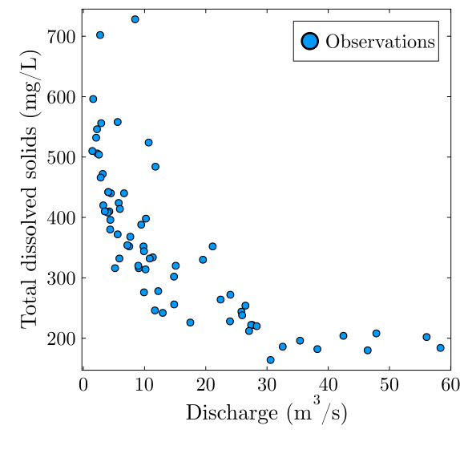

## How Does River Flow Affect TDS?

**Question**: Does river flow affect the concentration of total dissolved solids?

**Model**:
$$D \rightarrow S \ {\color{purple}\leftarrow U}$$
$$S = f(D, U)$$

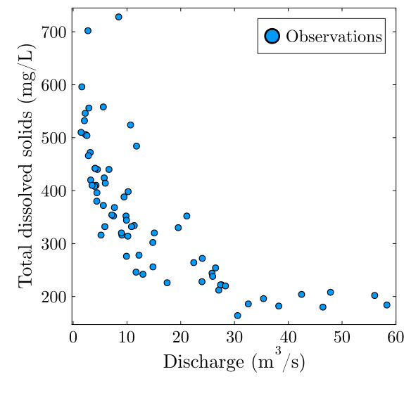

## Transforming Data

Can address non-linear relationship in this case with a transformation.

$$\begin{align*}
S &= \beta_0 + \beta_1 \log(D) + U\\
U &\sim \mathcal{N}(0, \sigma^2)
\end{align*}$$

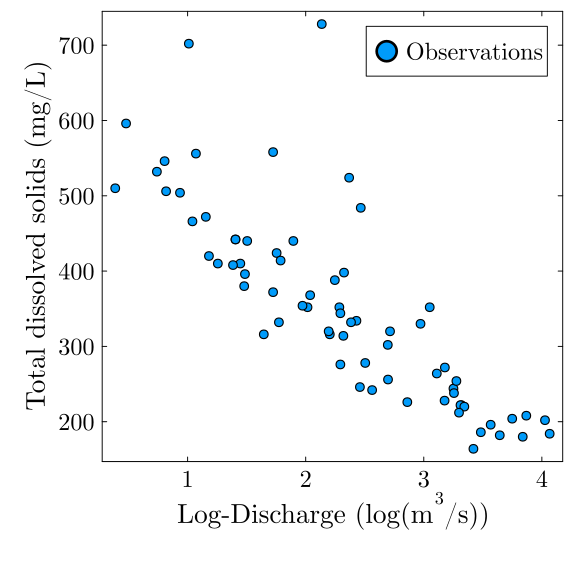

## Ordinary Least Squares

**Idea** (from Gauss and others): $S &= \beta_0 + \beta_1 \log(D)$ is an overdetermined system of equations.

Since we can’t solve, use minimization of sum of squared residuals as heuristic for a “good fit”.

$$S(b) = \sum_{i=1}^n (Y_i - X_i \beta)^2$$

If the columns of $X$ are linearly independent, this has a unique solution:
$$\hat{\beta} = \left(X^TX)^{-1}X^TY$$

## Variance of Errors

To get an estimate of the error variance $\hat{\sigma}^2$:

$$\hat{\sigma}^2 = \frac{(Y-X\hat{\beta})^T(Y-X\hat{\beta})}{n-p},$$

where $n$ is the number of data points and $p$ is the number of terms (here p=2).

## Linear Model Fitting: OLS

In this case:

```
β = inv(X' * X) * X' * Y = [609.5487272461871, -111.63106902057211]
s² = (ε' * ε) / (nrow(tds) - 2) = 5266.230284046526
```

```
5266.230284046526
```

## Properties of OLS Solution

The OLS solution is the **optimal linear predictor** given the least-squares criterion.

If you insist on a linear model, this is the best you can do.

This property does not require any assumptions on the distribution of $\varepsilon$.

## Linear Models Can Be Bad

While the linear predictor has no bias (averaged over all $X$), $\mathbb{E}[Y - X \hat{\beta}] = 0$…

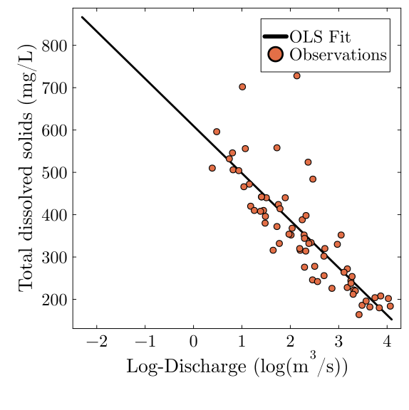

Figure 1: Linear regression fit to the TDS data.

```julia
# get predictions
x_pred = log.(0.1:0.1:60)
y_pred = β[1] .+ β[2] * x_pred
plot(x_pred, y_pred, label="OLS Fit", color=:black, linewidth=3,
    xlabel=L"Log-Discharge (log(m$^3$/s))",
    ylabel="Total dissolved solids (mg/L)",
    size=(600, 600))
scatter!(
    log.(tds.discharge_cms),
    tds.tds_mgL,
    markersize=5,
    label="Observations"
)
```

# Linear Regression As Probability Model

## Probabilistic Assumptions for LR

$$y &= \underbrace{\sum_j \beta_j x^j_i)}_{\mathbb{E}[y | x^j]} + \underbrace{\varepsilon_i}_{\text{noise}}, \quad \varepsilon_i \sim N(0, \sigma^2)$$

1. $\mathbb{E}[y | x^j]$: Best linear prediction of $y$ conditional on choice of predictors $x^j$.
2. The noise defines the probability distribution (here: Gaussian) of the observations:
   $$y \sim N(\sum_j \beta_j x^j_i), \sigma^2).$$

## Why Linear Models?

1. **Inferential**: “Least informative” distribution assuming only finite mean/variance;
2. **Generative**: Central Limit Theorem (summed fluctuations are asymptotically normal)
3. **Approximation**: Taylor expand “true” nonlinear model: maybe the higher order terms are small?

[figure not shown]

Weight stack Gaussian distribution

Source: r/GymMemes

## Central Limit Theorem

If

- $\mathbb{E}[X_i] = \mu$
- and $\text{Var}(X_i) = \sigma^2 < \infty$,

$$\begin{aligned}
\lim_{n \to \infty} \sqrt{n}(\bar{X}_n - \mu ) &= \mathcal{N}(0, \sigma^2) \\
\Rightarrow & \bar{X}_n \overset{\text{approx}}{\sim} \mathcal{N}(\mu, \sigma^2/n)
\end{aligned}$$

## Central Limit Theorem (More Intuitive)

For **a large enough set of samples**:

The sampling distribution of a sum or mean of random variables is approximately normal distribution, **even if the random variables themselves are not**.

[figure not shown]

Small n Meme

Source: Unknown

## Implications of Gaussian Noise

Without explicit modeling of sources of measurement uncertainty, in LR we can’t separate a noisy system state (due to *e.g.* omitted variables) from an uncertain measurement error (more on this later).

$$\begin{array}{l}
X \sim N(\mu_1, \sigma_1^2) \\
Y \sim N(\mu_2, \sigma_2^2) \\
Z = X + Y
\end{array}
\qquad \Rightarrow \qquad Z \sim N(\mu_1 + \mu_2, \sigma_1^2 + \sigma_2^2)$$

## Why Add Distributional Assumptions?

The distributional assumption of independent Gaussian residuals is **strong**.

# Key Points

## Probability Models

- Almost anything we want to use data for involves an assumption about the underlying probability model for the data.
- Our goal this semester is to develop a toolkit to specify, test, and use these probability models.

# Upcoming Schedule

## Next Classes

**Wednesday**: Fitting models with maximum likelihood

**Friday**: Maximum likelihood uncertainty

## Assessments

**Homework 1** Due Friday, 2/6.

# References

## References (Scroll for Full List)

Hacking, I. (1990). *The Taming of Chance*. Cambridge, England: Cambridge University Press. https://doi.org/10.1017/CBO9780511819766

Helsel, D. R., Hirsch, R. M., Ryberg, K. R., Archfield, S. A., & Gilroy, E. J. (2020). *Statistical methods in water resources* (research report No. 4-A3) (p. 484). Reston, VA: U.S. Geological Survey. Retrieved from http://pubs.er.usgs.gov/publication/tm4A3